# Reproductibility of Chosen R Journal Papers

Jakub Szypuła

31/03/2020

## Introduction

This report deals with reproductibility of three, chosen by the author, R Journal papers. In the paragraphs below, an attempt will be made to reproduce said papers.

## Mapping and Measuring Country Shapes

An article written by Nils B. Weidmann and Kristian Skrede Gleditsch, published in 2010.

[Link to the article](https://journal.r-project.org/archive/2010/RJ-2010-004/index.html)

### What is there to reproduce?

The article includes seven code chunks, however, only two are evaluated. The remaining five illustrate how one could implement certain tasks, using package provided by the authors (e.g. generating weights from a distance matrix). Therefore, reproducing these 5 code chunks is definitely possible, however, it is impossible to judge whether the code executes the way it was intended. The remaining two code chunks are dealt with below.

### Evaluated Code chunk #1

In the article the following code chunk is used to generate a world map, where each country’s color corresponds to its regime type in 2002.

```r
# download dataset, filter scores for 2002
polity.file <- paste(tempdir(), "p4v2008.sav", sep="/")
download.file("http://www.systemicpeace.org/inscr/p4v2008.sav", polity.file)
```

```
## Error in download.file("http://www.systemicpeace.org/inscr/p4v2008.sav", : cannot open URL 'http://www.systemicpeace.org/inscr/p4v2008.sav'
```

Unfortunately, the link above is dead. Consequently, the following code cannot be run, as it lacks the very data necessary to execute it.

```r
polity <- read.spss(polity.file, to.data.frame=T)
polity.2002 <- polity[polity$year==2002,]
polity.2002 <- subset(polity.2002, !is.na(polity2), select=c(ccode, polity2))
# generate a color palette
pal <- grey.colors(3, 0.25, 0.95)
# find the class intervals and colors
breaks <- classIntervals(cmap.2002.m$polity2,n=3, style="fixed", fixedBreaks=c(-10, -6, 7, 10))
colors <- findColours(breaks, pal)
# create plot and add legend
plot(cmap.2002.m, bty="n", col=colors)
legend(x="bottomleft",
legend=c("Autocracy", "Anocracy", "Democracy"),fill = attr(colors, "palette"),bty = "n", title="Regime type")
```

### Evaluated Code chunk #2

In this code chunk, a minimal distance matrix (i.e. a matrix where each element $A_{i, j}$ is the distance between country $i$ and $j$) is calculated twice, once using default tolerance parameter for the Douglas-Pecker polygon simplification algorithm and secondly using tolerance equal to 0 (no simplification).

```r
system.time(dmat.simple <- distmatrix(as.Date("2002-1-1"), type="mindist"))
```

```
##    user  system elapsed
##  134.25    0.50  137.25
```

```r
system.time(dmat.full <- distmatrix(as.Date("2002-1-1"), type="mindist", tolerance = 0))
```

```
##    user  system elapsed
## 6546.27  287.18 7646.58
```

```r
# correlation between the two
cor(as.vector(dmat.simple),as.vector(dmat.full))
```

```
## [1] 0.9987394
```

This time, the chunk was reproducible. Time to process the chunk was approximately halved, compared to the original. Interestingly, the correlation between the two matrices was slightly lower (~0.016%), than in the article.

### Summary

Out of 7 code chunks, 5 were not evaluated, one was evaluated and was reproduced successfully and one was evaluated, but it could not be reproduced. It was due to the fact, that the link to download the necessary data was expired.

## stplanr: A Package for Transport Planning

An article by Robin Lovelace, Richard Ellison, published in 2018.

[Link to the article](http://journal.r-project.org/archive/2018/RJ-2018-05a3/index.html)

An .R file was attached to the article, which helped with reproductibility.

### What is there to reproduce?

The article contains on evaluated code chunk and 8 figures, of which 7 were generated using R code.

### Setup and Figure 1

```r
if(!file.exists("reqfiles.RData"))
  download.file("https://github.com/Robinlovelace/stplanr/raw/rjournal-responses/lovelace/reqfiles.RData", "reqfiles.RData", mode = "wb")
load("reqfiles.RData")
rnet_buff_100 <- geo_buffer(route_network, width = 100)
```

```
## Transforming to CRS +proj=aeqd +lat_0=53.81840897 +lon_0=-1.52833461 +x_0=0 +y_0=0 +ellps=WGS84
```

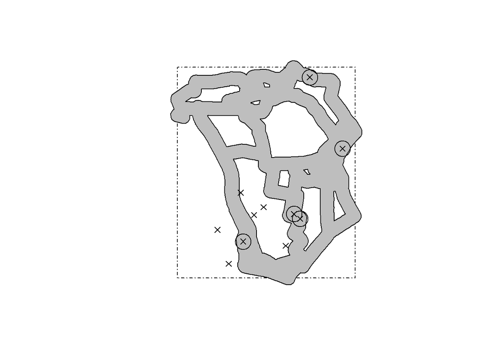

```r
ca_buff <- ca_local[rnet_buff_100,]
bb <- bb2poly(route_network)
plot(bb, lty = 4)
plot(rnet_buff_100, col = "grey", add = TRUE)
points(ca_local, pch = 4)
points(ca_buff, cex = 3)
```

One crucial change needed to be done - change of original `buff_geo` to `geo_buffer`, for the code to work. Since publication of the article, said function has been renamed.

### Evaluated table #1

Evaluated table means a dataframe presented in the default R way within the article.

```r
data("flow", package = "stplanr")
head(flow[c(1:3, 12)])
```

```
##        Area.of.residence Area.of.workplace All Bicycle
## 920573         E02002361         E02002361 109       2
## 920575         E02002361         E02002363  38       0
## 920578         E02002361         E02002367  10       0
## 920582         E02002361         E02002371  44       3
## 920587         E02002361         E02002377  34       0
## 920591         E02002361         E02002382   7       0
```

### Figure 3

```r
data("cents", package = "stplanr")
as.data.frame(cents[1:3, -c(3,4)])
```

```
##       geo_code  MSOA11NM coords.x1 coords.x2
## 1708 E02002384 Leeds 055 -1.546463  53.80952
## 1712 E02002382 Leeds 053 -1.511861  53.81161
## 1805 E02002393 Leeds 064 -1.524205  53.80410
```

```r
l <- od2line(flow = flow, zones = cents)
library(nycflights13)
airports_sf <- sf::st_as_sf(airports, coords = c("lon", "lat"), crs = 4326)
ny_buff <- geo_buffer(airports_sf[airports_sf$faa == "NYC",], dist = 1e6)
airports_near <- airports_sf[ny_buff,]
```

```
## although coordinates are longitude/latitude, st_intersects assumes that they are planar
## although coordinates are longitude/latitude, st_intersects assumes that they are planar
```

```r
flights_near <- flights[flights$dest %in% airports_near$faa,]
flights_agg <- dplyr::group_by(flights_near, origin, dest) %>%
  dplyr::summarise(Flights = n())
flights_sf = od2line(flow = flights_agg, zones = airports_near)

library(tmap)
tmap_mode("view")
```

```
## tmap mode set to interactive viewing
```

```r
pal <- viridis::viridis(n = 3, option = "C")
tm_shape(flights_sf) +
  tm_lines(lwd = "Flights", col = "Flights", scale = 12, n = 3, palette = "YlGnBu")
```

```
## Legend for line widths not available in view mode.
```

[interactive chart not shown]

There was a typo in the attached file - `flights_sp` instead of `flights_sf`.

### Figure 4

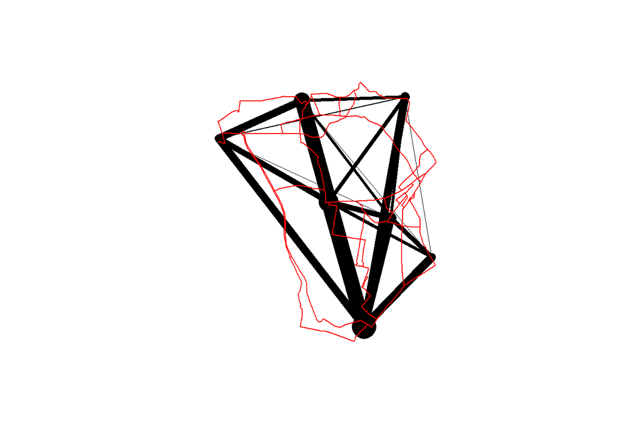

```r
plot(route_network, lwd=0)
plot(l, lwd = l$All / 10, add = TRUE)
lines(routes_fast, col = "red")
```

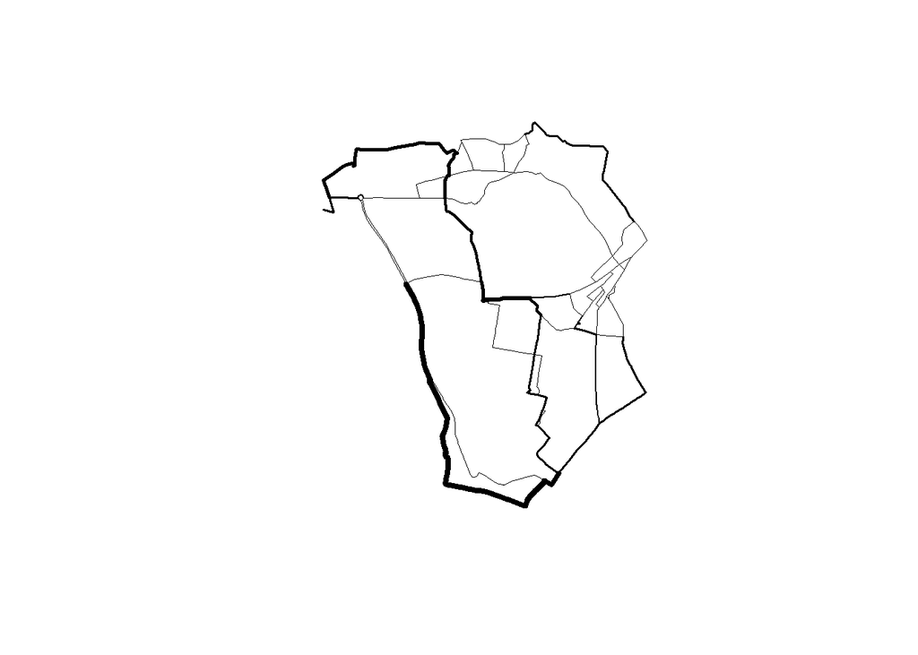

```r
routes_fast$All <- l$All
rnet <- overline(routes_fast, "All", fun = sum)
rnet$flow <- rnet$All / mean(rnet$All) * 3
plot(rnet, lwd = rnet$flow / mean(rnet$flow))
```

### Figure 5

```r
data_dir <- system.file("extdata", package = "stplanr")
unzip(file.path(data_dir, 'smallsa1.zip'))
unzip(file.path(data_dir, 'testcycleway.zip'))
sa1income <- rgdal::readOGR(".", "smallsa1", verbose= FALSE)
testcycleway <- rgdal::readOGR(".", "testcycleway", verbose= FALSE)
# Remove unzipped files
file.remove(list.files(pattern = "^(smallsa1|testcycleway).*"))
```

```
## [1] TRUE TRUE TRUE TRUE TRUE TRUE TRUE TRUE TRUE
```

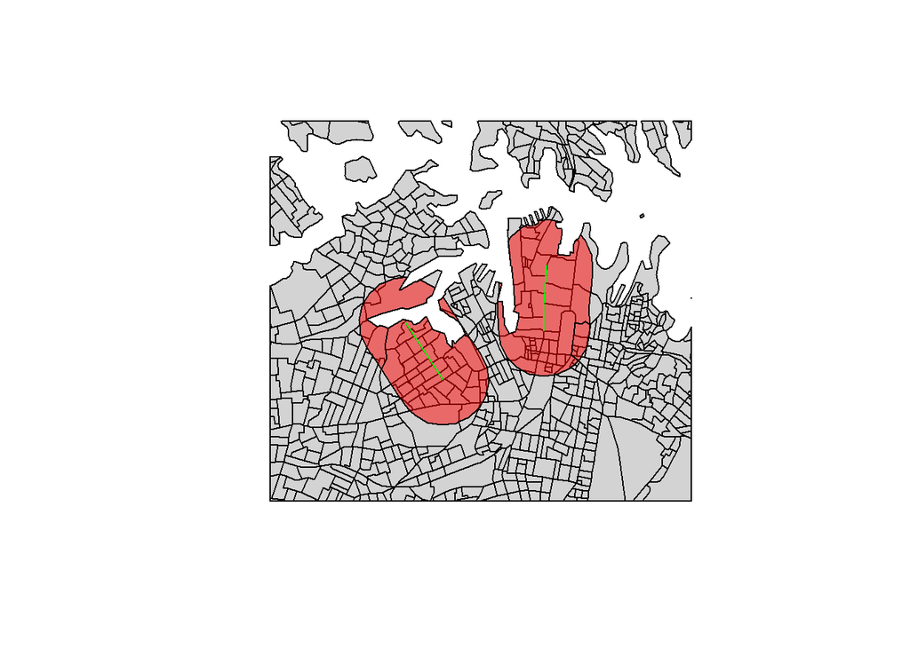

```r
catch800m <- calc_catchment(
  polygonlayer = sa1income,
  targetlayer = testcycleway,
  calccols = c('Total'),
  distance = 800,
  projection = 'austalbers',
  dissolve = TRUE
)

plot(sa1income, col = "light grey")
plot(catch800m, col = rgb(1, 0, 0, 0.5), add = TRUE)
plot(testcycleway, col = "green", add = TRUE)
```

### Figure 6

```r
unzip(file.path(data_dir, 'sydroads.zip'))
sydroads <- rgdal::readOGR(".", "roads", verbose = FALSE)
file.remove(list.files(pattern = "^(roads).*"))
```

```
## [1] TRUE TRUE TRUE TRUE TRUE
```

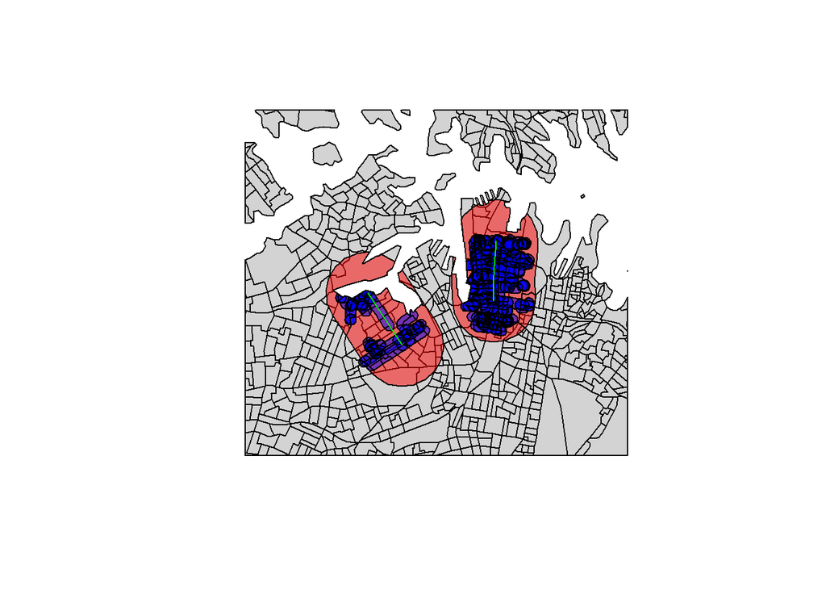

```r
sydnetwork <- SpatialLinesNetwork(sydroads)

netcatch800m <- calc_network_catchment(
  sln = sydnetwork,
  polygonlayer = sa1income,
  targetlayer = testcycleway,
  calccols = c('Total'),
  maximpedance = 800,
  distance = 100,
  projection = 'austalbers'
)

plot(sa1income, col = "light grey")
plot(catch800m, col = rgb(1, 0, 0, 0.5), add = TRUE)
plot(netcatch800m, col = rgb(0, 0, 1, 0.5), add = TRUE)
plot(testcycleway, col = "green", add = TRUE)
```

### Figure 7

```r
l$d_euclidean <- line_length(l)
```

```
## Transforming to CRS +proj=aeqd +lat_0=53.81907246 +lon_0=-1.52841182 +x_0=0 +y_0=0 +ellps=WGS84
```

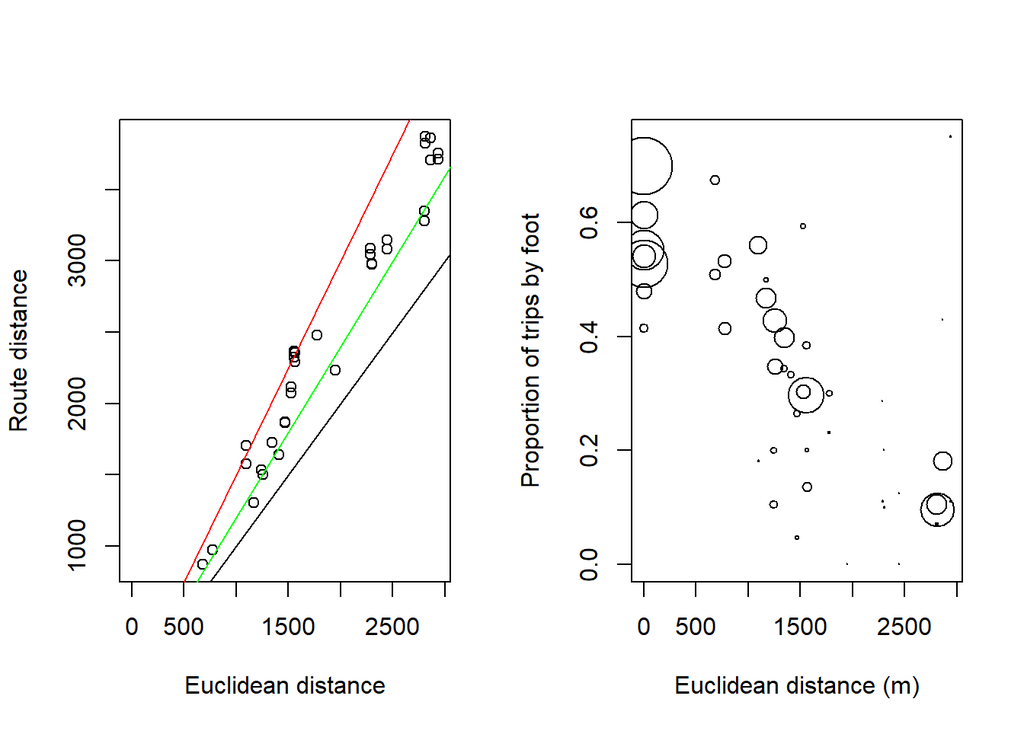

```r
l$d_rf <- routes_fast$length
## routes_slow <- line2route(l, route_cyclestreet, plan = "quietest")
l$d_rq <- routes_slow$length # quietest route distance
Q <- mean(l$d_rf / l$d_euclidean, na.rm = TRUE)
QDF <- mean(l$d_rq / l$d_rf, na.rm = TRUE)
QDFt <- mean(routes_slow$time / routes_fast$time, na.rm = TRUE)

## l$pwalk <- l$On.foot / l$All
## plot(l$d_euclidean, l$pwalk, cex = l$All / 50,
##   xlab = "Euclidean distance (m)", ylab = "Proportion of trips by foot")

par(mfrow = c(1, 2))
lgb <- sp::spTransform(l, CRSobj = CRS("+init=epsg:27700"))
l$d_euclidean <- rgeos::gLength(lgb, byid = T)
l$d_rf <- routes_fast@data$length
plot(l$d_euclidean, l$d_rf,
     xlab = "Euclidean distance", ylab = "Route distance")
abline(a = 0, b = 1)
abline(a = 0, b = 1.2, col = "green")
abline(a = 0, b = 1.5, col = "red")
l$pwalk <- l$On.foot / l$All
plot(l$d_euclidean, l$pwalk, cex = l$All / 50,
     xlab = "Euclidean distance (m)", ylab = "Proportion of trips by foot")
```

### Figure 8

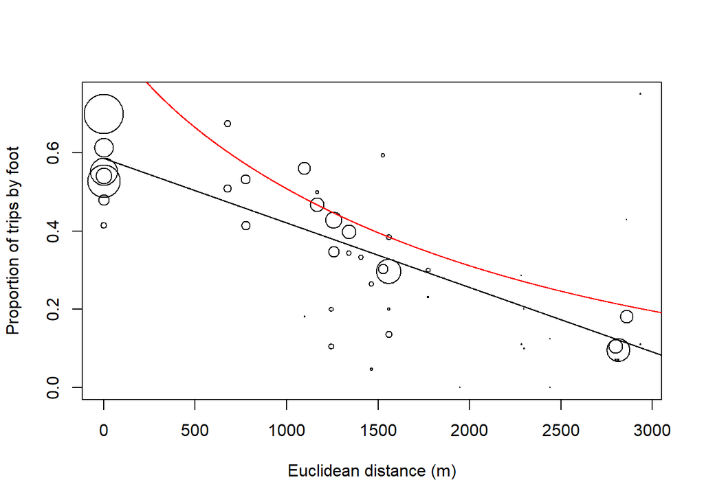

```r
lm1 <- lm(pwalk ~ d_euclidean, data = l@data, weights = All)
lm2 <- lm(pwalk ~ d_rf, data = l@data, weights = All)
lm3 <- glm(pwalk ~ d_rf + I(d_rf^0.5),
           data = l@data, weights = All, family = quasipoisson(link = "log"))
plot(l$d_euclidean, l$pwalk, cex = l$All / 50,
     xlab = "Euclidean distance (m)", ylab = "Proportion of trips by foot")
l2 <- data.frame(d_euclidean = 1:5000, d_rf = 1:5000)
lm1p <- predict(lm1, l2)
lm2p <- predict(lm2, l2)
lm3p <- predict(lm3, l2)
lines(l2$d_euclidean, lm1p)
lines(l2$d_euclidean, exp(lm2p), col = "green")
lines(l2$d_euclidean, exp(lm3p), col = "red")
```

### Summary

Thanks to the attached .R file, reproducing this article has been relatively easy. There were minor mistakes, but attempt to reproduce the results directly from the article would have been futile, for most of `strplanr` functions used there have been either removed, moved to `stats19` or renamed.

## Furniture for Quantitative Scientists

An article by Tyson S. Barrett and Emily Brignone, published in 2017.

[Link to the article](https://journal.r-project.org/archive/2017/RJ-2017-037/index.html)

Curiously, this article mentions reproductibility itself. The authors imply that the `furniture` package could be used to provide sample summary statistics, simplifying the process of replicating the results.

### What is there to reproduce?

The article contains 9 code chunks, 4 are evaluted and one produces a figure.

### Evaluated Code Chunk #1

```r
table1(d1,
  gender, age, active, marijuana, illicit,
  down, sleeping, low_energy, appetite, feel_bad,
  dead, difficulty,
  splitby = ~overweight,
  test = TRUE,
  output = "text2")
```

```
##
## ----------------------------------------------------
##                        overweight
##                  Yes          No            P-Value
##                  n = 39       n = 153
##  --------------- ------------ ------------- -------
##  gender                                     0.753
##     Male         22 (56.4%)   93 (60.8%)
##     Female       17 (43.6%)   60 (39.2%)
##  age                                        0.921
##                  23.1 (4.2)   23.1 (3.8)
##  active                                     0.503
##                  149.6 (91.0) 162.4 (109.7)
##  marijuana                                  0.623
##     Yes          27 (69.2%)   97 (63.4%)
##     No           12 (30.8%)   56 (36.6%)
##  illicit                                    0.145
##     Yes          2 (5.1%)     24 (15.7%)
##     No           37 (94.9%)   129 (84.3%)
##  down                                       0.376
##     No           28 (71.8%)   125 (81.7%)
##     Several Days 8 (20.5%)    24 (15.7%)
##     Majority     2 (5.1%)     3 (2%)
##     Everyday     1 (2.6%)     1 (0.7%)
##  sleeping                                   0.961
##     No           18 (46.2%)   76 (49.7%)
##     Several Days 15 (38.5%)   54 (35.3%)
##     Majority     4 (10.3%)    17 (11.1%)
##     Everyday     2 (5.1%)     6 (3.9%)
##  low_energy                                 0.987
##     No           11 (28.2%)   46 (30.1%)
##     Several Days 23 (59%)     88 (57.5%)
##     Majority     4 (10.3%)    14 (9.2%)
##     Everyday     1 (2.6%)     5 (3.3%)
##  appetite                                   0.025
##     No           21 (53.8%)   116 (75.8%)
##     Several Days 15 (38.5%)   31 (20.3%)
##     Majority     3 (7.7%)     6 (3.9%)
##     Everyday     0 (0%)       0 (0%)
##  feel_bad                                   0.082
##     No           26 (66.7%)   125 (81.7%)
##     Several Days 12 (30.8%)   21 (13.7%)
##     Majority     1 (2.6%)     5 (3.3%)
##     Everyday     0 (0%)       2 (1.3%)
##  dead                                       0.703
##     No           37 (94.9%)   148 (96.7%)
##     Several Days 1 (2.6%)     3 (2%)
##     Majority     1 (2.6%)     1 (0.7%)
##     Everyday     0 (0%)       1 (0.7%)
##  difficulty                                 1
##     No           33 (84.6%)   129 (84.3%)
##     Several Days 6 (15.4%)    24 (15.7%)
##     Majority     0 (0%)       0 (0%)
##     Everyday     0 (0%)       0 (0%)
## ----------------------------------------------------
```

### Evaluated Code Chunk #2

```r
table1(d1,
  gender, age, active, marijuana,
  splitby = ~overweight,
  test = TRUE,
  output = "text2",
  second = c("age", "active"))
```

```
##
## ----------------------------------------------
##                  overweight
##            Yes          No            P-Value
##            n = 57       n = 225
##  --------- ------------ ------------- -------
##  gender                               0.567
##     Male   33 (57.9%)   142 (63.1%)
##     Female 24 (42.1%)   83 (36.9%)
##  age                                  0.481
##            22.0 [8.0]   23.0 [7.0]
##  active                               0.294
##            120.0 [90.0] 125.0 [135.0]
##  marijuana                            0.918
##     Yes    35 (61.4%)   134 (59.6%)
##     No     22 (38.6%)   91 (40.4%)
## ----------------------------------------------
```

### Evaluated Code Chunk #3

```r
table1(d1,
  gender, age, active,
  splitby = ~overweight,
  test = TRUE,
  output = "text2",
  FUN = function(x) paste0(min(x, na.rm=TRUE), ", ", max(x, na.rm=TRUE)))
```

```
##
## ------------------------------------------
##                overweight
##            Yes        No          P-Value
##            n = 66     n = 251
##  --------- ---------- ----------- -------
##  gender                           0.666
##     Male   39 (59.1%) 158 (62.9%)
##     Female 27 (40.9%) 93 (37.1%)
##  age                              0.765
##            18, 30     18, 30
##  active                           0.282
##            30, 505    20, 840
## ------------------------------------------
```

### Evaluated Code Chunk #4

```r
table1(d1,
  gender, age, active, marijuana, illicit, down,
  splitby = ~overweight,
  test = TRUE,
  output = "text2",
  type = c("simple", "condense"))
```

```
##
## ----------------------------------------------------
##                        overweight
##                  Yes          No            P-Value
##                  n = 57       n = 225
##  --------------- ------------ ------------- -------
##  gender: Female  42.1%        36.9%         0.567
##  age             22.9 (4.2)   23.3 (3.8)    0.481
##  active          150.3 (90.1) 166.6 (108.6) 0.294
##  marijuana: No   38.6%        40.4%         0.918
##  illicit: No     94.7%        86.7%         0.144
##  down                                       0.389
##     No           80.7%        87.6%
##     Several Days 14%          10.7%
##     Majority     3.5%         1.3%
##     Everyday     1.8%         0.4%
## ----------------------------------------------------
```

### Figure 1

```r
table1(d1,
  gender, age, active, marijuana, illicit,
  down, sleeping, dead,
  splitby = ~overweight,
  var_names = c("Gender", "Age", "Activity (minutes)", "Marijuana",
  "Other Illicit Drug", "Feeling Down",
  "Trouble Sleeping", "Wish Were Dead"),
  format_number = TRUE,
  type = "simple",
  test = TRUE,
  output = "latex")
```

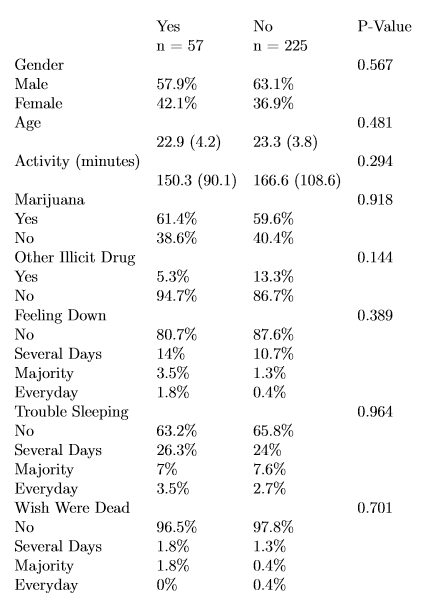

Latex table

Unfortunately, since this is an HTML document (and conversion to PDF would have meant rerunning all the code, including ~2 hours long chunk in the first article) I resorted to including an image of the resulting table. The latex code returned by the `table1` runs smoothly.

### Summary

This article, despite not having an .R file included was also relatively easy to reproduce.

## General Summary

Out of the three analysed articles, one could not be fully reproduced, one needed minor changes and one could be reproduced without issues (other than latex output in an HTML document, which is unrelated to the paper itself). I identified two major obstacles in the reproductibility of research papers, both related to the passage of time:

- data necessary to reproduce the article no longer being available
- functions used in the paper being either renamed, removed or moved to other packages